# KL-divergence

Christian Knudsen

5/1/2022

KL-divergence

Også kendt som Kullback-Leibler divergence, eller “relativ entropi”.

Et mål for statistisk afstand, hvor meget en sandsynlighedsfordeling Q er fra en anden fordeling P.

Vi kan også tænke på den som hvor godt to fordelinger matcher.

Tallene i eksemplerne er fra: https://towardsdatascience.com/light-on-math-machine-learning-intuitive-guide-to-understanding-kl-divergence-2b382ca2b2a8

https://en.wikipedia.org/wiki/Kullback%E2%80%93Leibler_divergence

Vi har en observeret fordeling. Thushan er tydeligvis fan af Dune, og har dette eksempeldatasæt:

```r
space_worm_teeth <- c(rep(0 ,2 ),
rep(1 ,3 ),
rep(2 ,5 ),
rep(3 ,14),
rep(4 ,16),
rep(5 ,15),
rep(6 ,12),
rep(7 ,8 ),
rep(8 ,10),
rep(9 ,8 ),
rep(10, 7))
space_worm_teeth <- space_worm_teeth %>%
  as_tibble_col(column_name = "space_worm_teeth")   %>%
  count(space_worm_teeth) %>%
  mutate(prob = n/sum(n))
```

Han forklarer det med at vi har 100 rumorme. de to af dem har 0 tænder, de tre af dem 1 tand, de fem af dem 2 tænder og så fremdeles.

Det ser således ud når vi plotter det:

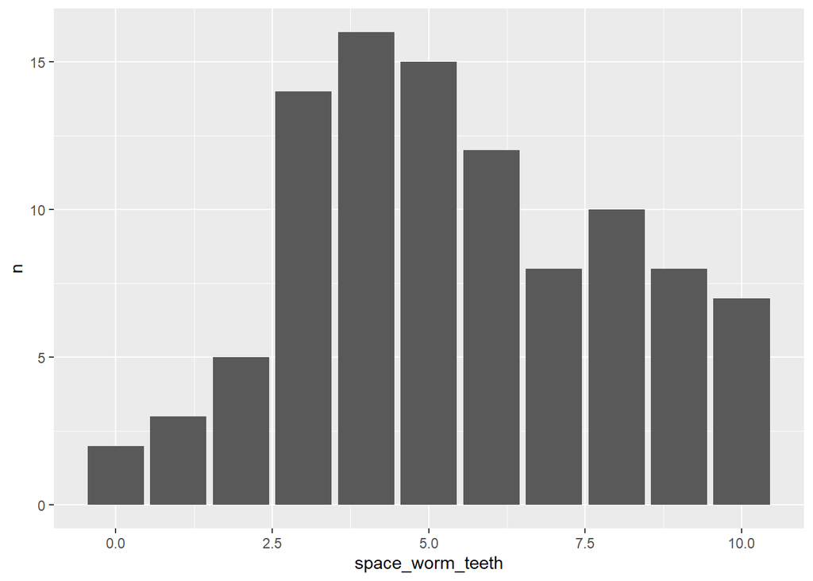

```r
ggplot(space_worm_teeth, aes(space_worm_teeth, n)) +
  geom_col()
```

Det er vores “sande” fordeling, det vi har observeret. Der er 100 rumorme ialt, så når der er 2 orme med 0 tænder, er sandsynligheden for at observere 0 tænder 0.02

Så når vi plotter det som en sandsynlighedsfordeling, får vi:

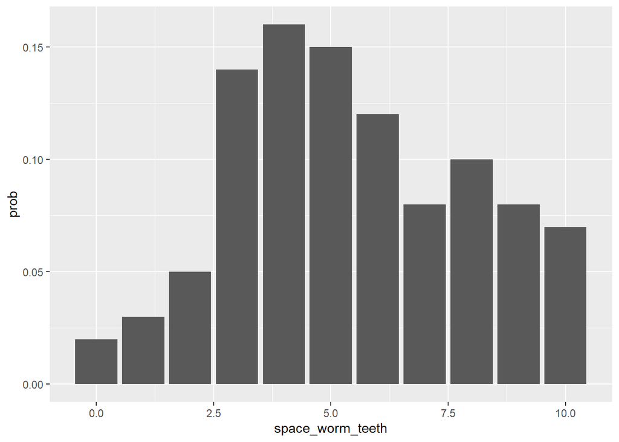

```r
ggplot(space_worm_teeth, aes(space_worm_teeth, prob)) +
    geom_col()
```

Det er fint. Vi er interesserede i at vide hvilken fordeling antallet af tænder hos vores rumorme har.

Vi kunne antage at der er en uniform fordeling. Altså at sandsynligheden for at en given orm har 0 tænder, er den samme som at den har 1 tand. Eller 2. Eller 3. You get the point.

Det ville se således ud:

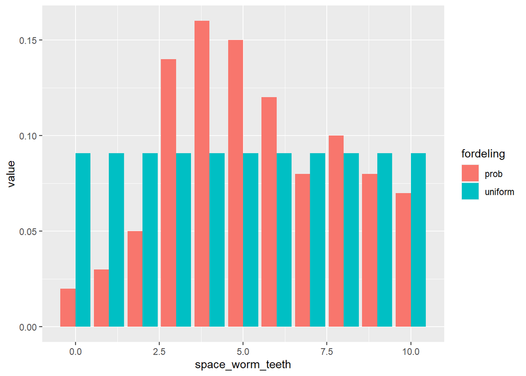

```r
space_worm_teeth %>%
  mutate(uniform = 1/11) %>%
  pivot_longer(prob:uniform,
               names_to = "fordeling",
               values_to = "value") %>%
  ggplot(aes(space_worm_teeth, value, fill=fordeling)) +
  geom_col(position="dodge")
```

Det er tydeligvis en fordeling der ikke matcher virkeligheden særligt godt.

Hvad hvis vi prøver med en binomial fordeling. Det er den fordeling vi får, når vi regner på sandsynligheder for hvor mange plat og hvor mange krone vi får når vi kaster med mønter.

Udseendet af den afhænger af hvilken sandsynlighed der er for at vi får succes, eg plat. Hvis den er 50%, ser det således ud:

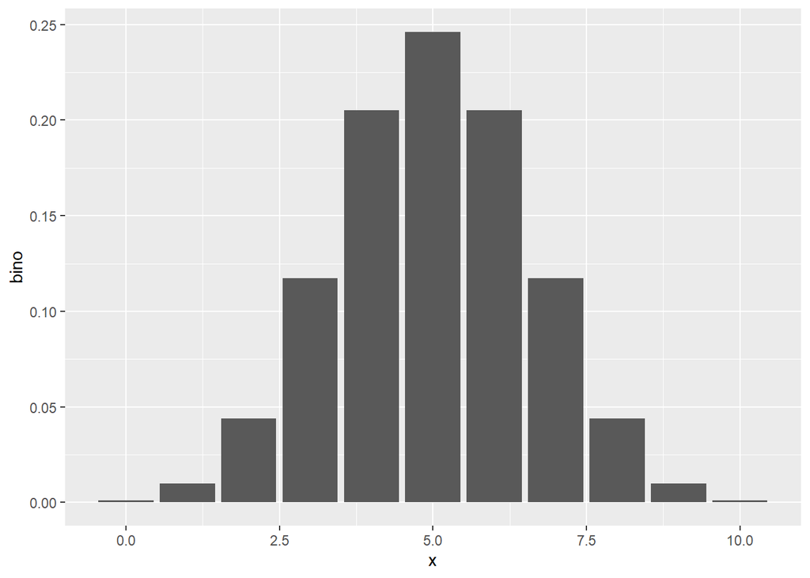

```r
data.frame(x=0:10) %>%
  mutate(bino = dbinom(x,10,0.5)) %>%
  ggplot(aes(x,bino)) +
  geom_col()
```

Plottet viser hvad sandsynligheden er for at vi får x “plat” når vi slår plat og krone.

Men i samme øjeblik vi ændrer på den sandsynlighed, skifter plottet udseende:

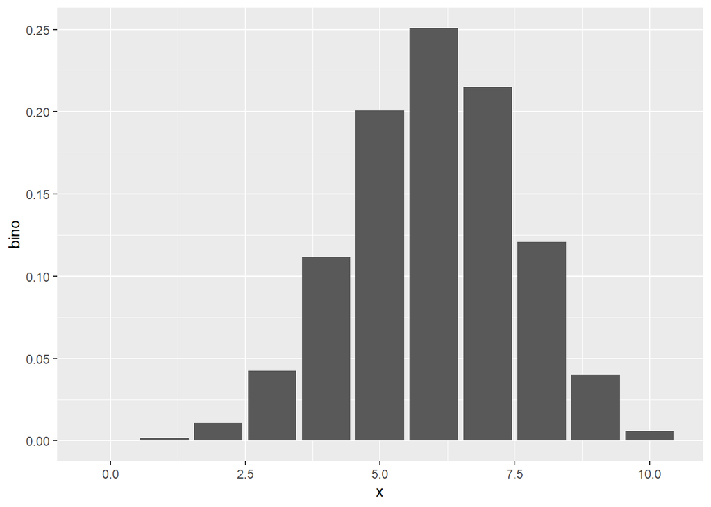

```r
data.frame(x=0:10) %>%
  mutate(bino = dbinom(x,10,0.6)) %>%
  ggplot(aes(x,bino)) +
  geom_col()
```

Her har jeg ændret sandsynligheden for at få plat til at være 60% - en ret unfair mønt, og nu ser det noget anderledes ud. Fem plat optræder kun med 20% sandsynlighed.

Og ændrer vi endnu mere på det, så går det helt galt:

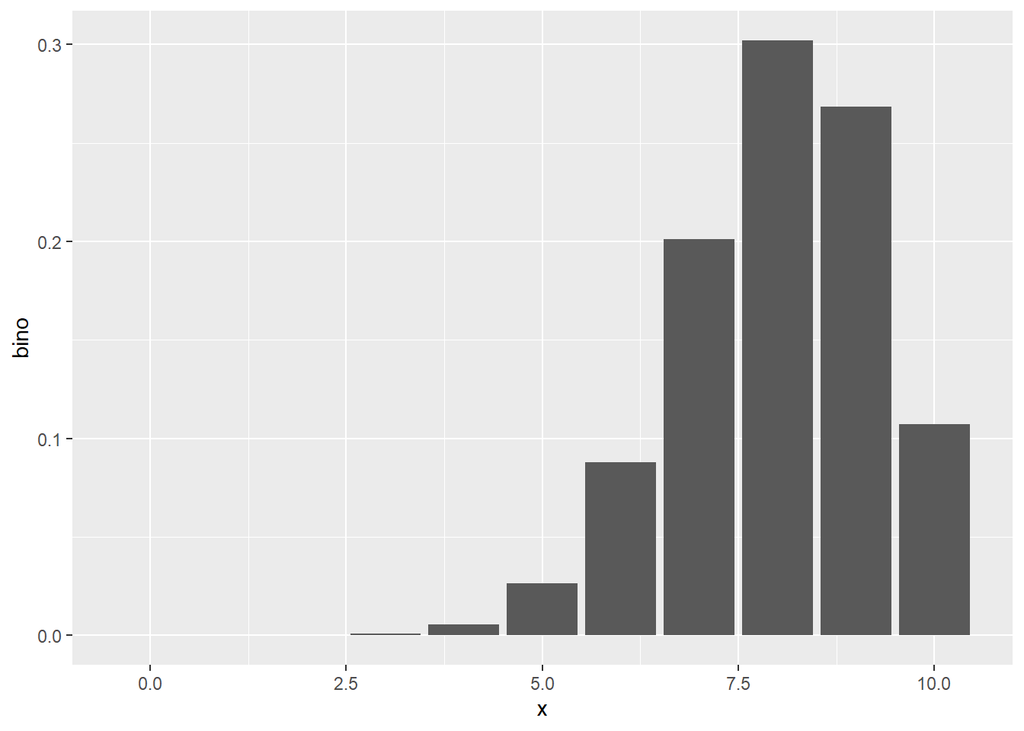

```r
data.frame(x=0:10) %>%
  mutate(bino = dbinom(x,10,0.8)) %>%
  ggplot(aes(x,bino)) +
  geom_col()
```

Her har vi gang i en meget unfair mønt, der giver plat 80% af gangene.

Så hvis vi vil have et bud på hvordan binomialfordelingen for vores rumormes tænder, skal vi have en ide om hvad sandsynligheden for at der er en tand er.

Vi starter med at finde ud af hvad det gennemsnitlige antal tænder er:

```r
c(rep(0 ,2 ),
rep(1 ,3 ),
rep(2 ,5 ),
rep(3 ,14),
rep(4 ,16),
rep(5 ,15),
rep(6 ,12),
rep(7 ,8 ),
rep(8 ,10),
rep(9 ,8 ),
rep(10, 7)) %>% mean()
```

```
## [1] 5.44
```

Hvorfor er n = 10, og ikke 100? Det skal jeg lige vride hjernen omkring…

Anyway, sandsynligheden er 0.544

Nu kan vi beregne hvad sandsynligheden for at observere et bestemt antal tænder er:

```r
space_worm_teeth %>%
  mutate(binom = dbinom(space_worm_teeth, 10, 0.544))
```

```
## # A tibble: 11 x 4
##    space_worm_teeth     n  prob    binom
##               <dbl> <int> <dbl>    <dbl>
##  1                0     2  0.02 0.000389
##  2                1     3  0.03 0.00464
##  3                2     5  0.05 0.0249
##  4                3    14  0.14 0.0792
##  5                4    16  0.16 0.165
##  6                5    15  0.15 0.237
##  7                6    12  0.12 0.235
##  8                7     8  0.08 0.160
##  9                8    10  0.1  0.0718
## 10                9     8  0.08 0.0190
## 11               10     7  0.07 0.00227
```

og vi kan plotte det, sammen med vores oprindelige fordeling af tænder:

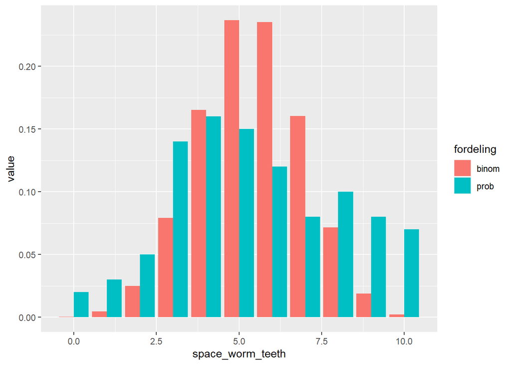

```r
space_worm_teeth %>%
  mutate(binom = dbinom(space_worm_teeth, 10, 0.544)) %>%
  select(space_worm_teeth, prob, binom) %>%
  pivot_longer(prob:binom,
               names_to = "fordeling",
               values_to = "value") %>%
  ggplot(aes(space_worm_teeth, value, fill = fordeling)) +
  geom_col(position = "dodge")
```

Man kunne være fristet til at sige at det ligner mere. Men hvor meget mere?

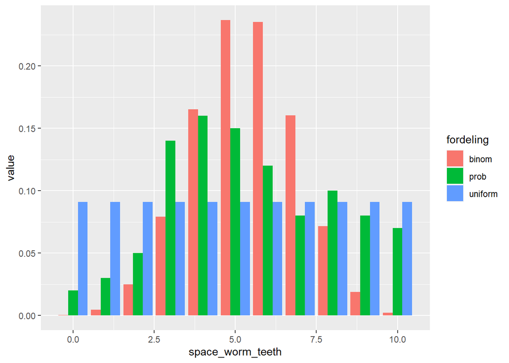

```r
space_worm_teeth %>%
  mutate(uniform = 1/11) %>%
  mutate(binom = dbinom(space_worm_teeth, 10, 0.544)) %>%
  pivot_longer(prob:binom,
               names_to = "fordeling",
               values_to = "value") %>%
  ggplot(aes(space_worm_teeth, value, fill = fordeling)) +
  geom_col(position = "dodge")
```

det er prob der er den “sande” fordeling. Hvor godt matcher de to andre den?

Den er defineret som:

$$D_{KL}(p||q) = \sum_{i=1}^N p(x_i)\log(\frac{p(x_i)}{q(x_i)})$$

Og hvad katten betyder det? På venstre side af lighedstegnet har vi bare den fancy måde at skrive “KL-divergensen mellem de to fordelinger p og q”. Her er p den “sande” fordeling. Og q er den fordeling vi vil måle afstanden til. Men vi kan ligeså godt måle afstanden mellem andre fordelinger.

På højre side af lighedstegnet, har vi summationstegnet. Vi lader i gå fra i til N, og så lægger vi de værdier sammen der står efter tegnet. 1 er den første observation, her 0 tænder. og så lader vi den tælle op til vi når de 10 tænder.

Dernæst: $p(x_i)$. Det er sandsynligheden for at vi observerer $x_i$ tænder efter fordelingen p. Den første observation er hvor x er lig 0. Den sandsynlighed ganger vi med logaritmen til en brøk. Og den brøk er så sandsynligheden for at vi ser x tænder efter fordelingen p, divideret med sandsynligheden for at vi ser x tænder efter fordelingen q.

Hvad sker der? Hvis de to sandsynligheder er ens, er brøken lig 1. Og logaritmen til 1 er 0. Så hvis de to sandsynligheder er ens, er hele summen 0.

Anyway, lad os beregne forskellen mellem den sande værdi, og de to fordelinger:

```r
space_worm_teeth %>%
  mutate(uniform = 1/11) %>%
  mutate(binom = dbinom(space_worm_teeth, 10, 0.544)) %>%
  mutate(kl_uniform = prob*log(prob/uniform)) %>%
  mutate(kl_binom = prob*log(prob/binom)) %>%
  summarise(KL_uniform = sum(kl_uniform),
            KL_binom = sum(kl_binom))
```

```
## # A tibble: 1 x 2
##   KL_uniform KL_binom
##        <dbl>    <dbl>
## 1      0.137    0.427
```

Jo tættere værdien er på 0, jo bedre matcher fordelingen “sandheden”. Og selvom vi tidligere blev fristet til at mene at binomial-fordelingen så mere rigtig ud, så er den uniforme fordeling faktisk bedre.